# 環境作成と動作確認

本ページはデータ分析勉強会で行うチュートリアルファイルを動かすために必要なパッケージのインストールとインストール後の動作確認方法について記述しています。

# パッケージのインストール

## R GUIからのインストール

R（R GUI）のメニューからインストールする場合はパッケージのインストールを参照して個々のパッケージを順に指定してインストールして下さい。

## RStudioからのインストール

RStudioからインストールする場合は［Packages］パネルにある［Install］ボタンをクリックして表示されるダイアログの［Packages］欄に以下のように入力して［Install］ボタンをクリックします。

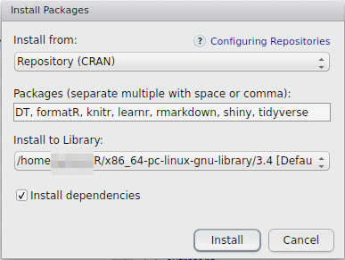

## R Consoleからのインストール

R GUI, R Commander, RStudioのコンソールからスクリプトを用いて直接インストールする場合は以下のコマンドを実行して下さい。

```r
chooseCRANmirror()
pkg_lst <- c("DT", "formatR", "knitr", "learnr", "rmarkdown", "shiny", "tidyverse")
install.packages(pkg_lst, dependencies = TRUE)
```

# RStudioの動作確認

チュートリアルに必要なパッケージをインストールしましたら以下の手順でRStudioを用いて動作確認を行います。

## 新規ファイルの作成

RStudioの左上のアイコンから［R Markdown…］をクリックするか麺ヒューから［File］-［New File］-［R Markdown…］を選択します。

[figure not shown]

## テンプレートの選択

テンプレート選択画面が開きますので左側のリストから［From Template］を選択し右側に表示されたテンプレート一覧から［Interactive Tutorial］を選択し［OK］ボタンをクリックします。

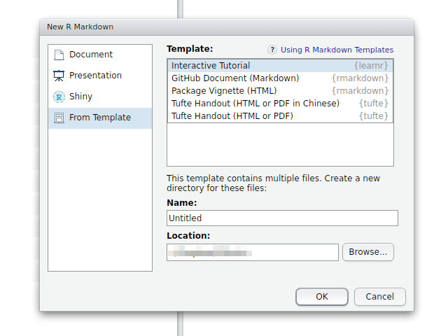

## ドキュメントのレンダリング

テンプレートが開きましたら［Run Document］ボタンをクリックして下さい。R Markdownファイルのレンダリングが実行されます。

[figure not shown]

## ドキュメントの実行

レンダリングが終了し［Viewer］パネルに下図のような表示が出れば動作確認終了です。

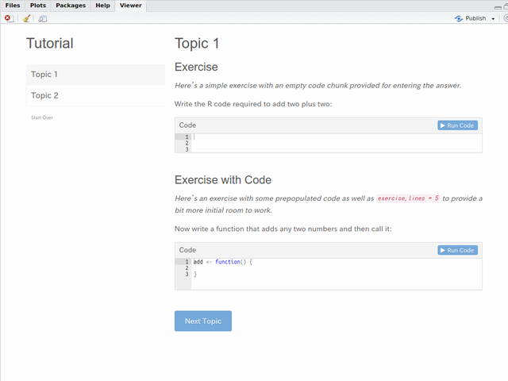

# 困った場合は

［Console］パネルまたは［R Markdown］パネルにエラーメッセージが表示されていますので、それらを参考に不足しているパッケージをインストールして下さい。特にWindows環境ではUACが原因でパッケージのインストールができない場合もありますので、管理者権限でアプリケーションを立ち上げから実行してください。

[CC BY-NC-SA 4.0](http://creativecommons.org/licenses/by-nc-sa/4.0/deed.ja), Sampo Suzuki [2017-07-26 18:05(JST)]

# 環境作成と動作確認

本ページはデータ分析勉強会で行うチュートリアルファイルを動かすために必要なパッケージのインストールとインストール後の動作確認方法について記述しています。

# パッケージのインストール

## R GUIからのインストール

R（R GUI）のメニューからインストールする場合はパッケージのインストールを参照して個々のパッケージを順に指定してインストールして下さい。

## RStudioからのインストール

RStudioからインストールする場合は［Packages］パネルにある［Install］ボタンをクリックして表示されるダイアログの［Packages］欄に以下のように入力して［Install］ボタンをクリックします。

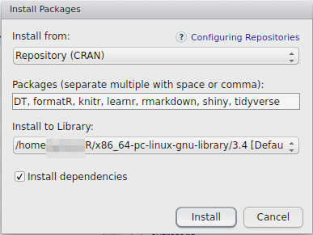

## R Consoleからのインストール

R GUI, R Commander, RStudioのコンソールからスクリプトを用いて直接インストールする場合は以下のコマンドを実行して下さい。

```r
chooseCRANmirror()
pkg_lst <- c("DT", "formatR", "knitr", "learnr", "rmarkdown", "shiny", "tidyverse")
install.packages(pkg_lst, dependencies = TRUE)
```

# RStudioの動作確認

チュートリアルに必要なパッケージをインストールしましたら以下の手順でRStudioを用いて動作確認を行います。

## 新規ファイルの作成

RStudioの左上のアイコンから［R Markdown…］をクリックするか麺ヒューから［File］-［New File］-［R Markdown…］を選択します。

[figure not shown]

## テンプレートの選択

テンプレート選択画面が開きますので左側のリストから［From Template］を選択し右側に表示されたテンプレート一覧から［Interactive Tutorial］を選択し［OK］ボタンをクリックします。

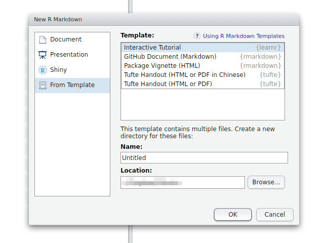

## ドキュメントのレンダリング

テンプレートが開きましたら［Run Document］ボタンをクリックして下さい。R Markdownファイルのレンダリングが実行されます。

[figure not shown]

## ドキュメントの実行

レンダリングが終了し［Viewer］パネルに下図のような表示が出れば動作確認終了です。

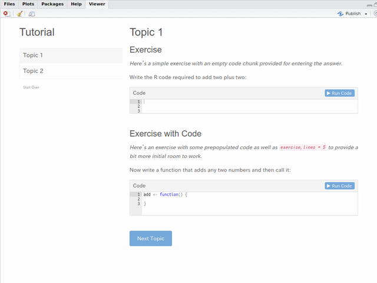

# 困った場合は

［Console］パネルまたは［R Markdown］パネルにエラーメッセージが表示されていますので、それらを参考に不足しているパッケージをインストールして下さい。特にWindows環境ではUACが原因でパッケージのインストールができない場合もありますので、管理者権限でアプリケーションを立ち上げから実行してください。

[CC BY-NC-SA 4.0](http://creativecommons.org/licenses/by-nc-sa/4.0/deed.ja), Sampo Suzuki [2017-07-26 18:05(JST)]